# CalCOFI

<h1 align="center">Prediction of Ocean Temperature and Salinity Using ML</h1> <p align="center">**Federico Sanchini**</p> <p align="center">26/06/2025</p> <hr />

<h2 id="Linear-Regression-with-Ridge-Regularization-and-Mercer-Kernels-for-the-Prediction-of-Ocean-Temperature-and-Salinity">**Linear Regression with Ridge Regularization and Mercer Kernels for the Prediction of Ocean Temperature and Salinity**</h2>

```python
import numpy as np
import matplotlib.pyplot as plt
import pandas as pd
import os
import seaborn as sns
from sklearn.model_selection import train_test_split
from sklearn.kernel_approximation import RBFSampler
from sklearn.linear_model import Ridge
from sklearn.pipeline import make_pipeline
from sklearn.preprocessing import StandardScaler

# Load the CSV file using ";" as the separator
file_path = 'bottle.csv'
df = pd.read_csv(file_path, sep=';')

# Display the first rows of the dataframe
df.head()
```

<style scoped> .dataframe tbody tr th:only-of-type { vertical-align: middle; } .dataframe tbody tr th { vertical-align: top; } .dataframe thead th { text-align: right; } </style> <thead> <th></th> <th>Cst_Cnt</th> <th>Btl_Cnt</th> <th>Sta_ID</th> <th>Depth_ID</th> <th>Depthm</th> <th>T_degC</th> <th>Salnty</th> <th>O2ml_L</th> <th>STheta</th> <th>O2Sat</th> <th>...</th> <th>R_PHAEO</th> <th>R_PRES</th> <th>R_SAMP</th> <th>dic-01</th> <th>dic-02</th> <th>TA1</th> <th>TA2</th> <th>pH2</th> <th>pH1</th> <th>DIC Quality Comment</th> </thead> <tbody> <th>0</th> <th>1</th> <th>2</th> <th>3</th> <th>4</th> </tbody>

| 1 | 1 | 054.0 056.0 | 19-4903CR-HY-060-0930-05400560-0000A-3 | 0 | 10.50 | 33.440 | NaN | 25.649 | NaN | ... | NaN | 0 | NaN | NaN | NaN | NaN | NaN | NaN | NaN | NaN |
| --- | --- | --- | --- | --- | --- | --- | --- | --- | --- | --- | --- | --- | --- | --- | --- | --- | --- | --- | --- | --- |
| 1 | 2 | 054.0 056.0 | 19-4903CR-HY-060-0930-05400560-0008A-3 | 8 | 10.46 | 33.440 | NaN | 25.656 | NaN | ... | NaN | 8 | NaN | NaN | NaN | NaN | NaN | NaN | NaN | NaN |
| 1 | 3 | 054.0 056.0 | 19-4903CR-HY-060-0930-05400560-0010A-7 | 10 | 10.46 | 33.437 | NaN | 25.654 | NaN | ... | NaN | 10 | NaN | NaN | NaN | NaN | NaN | NaN | NaN | NaN |
| 1 | 4 | 054.0 056.0 | 19-4903CR-HY-060-0930-05400560-0019A-3 | 19 | 10.45 | 33.420 | NaN | 25.643 | NaN | ... | NaN | 19 | NaN | NaN | NaN | NaN | NaN | NaN | NaN | NaN |
| 1 | 5 | 054.0 056.0 | 19-4903CR-HY-060-0930-05400560-0020A-7 | 20 | 10.45 | 33.421 | NaN | 25.643 | NaN | ... | NaN | 20 | NaN | NaN | NaN | NaN | NaN | NaN | NaN | NaN |

<p>5 rows × 74 columns</p>

```python
df.info()
```

```
<class 'pandas.core.frame.DataFrame'>
RangeIndex: 864863 entries, 0 to 864862
Data columns (total 74 columns):
 #   Column               Non-Null Count   Dtype
---  ------               --------------   -----
 0   Cst_Cnt              864863 non-null  int64
 1   Btl_Cnt              864863 non-null  int64
 2   Sta_ID               864863 non-null  object
 3   Depth_ID             864863 non-null  object
 4   Depthm               864863 non-null  int64
 5   T_degC               853900 non-null  float64
 6   Salnty               817509 non-null  float64
 7   O2ml_L               696201 non-null  float64
 8   STheta               812174 non-null  float64
 9   O2Sat                661274 non-null  float64
```

[output cut: 66 more lines]

<p>The columns of interest are:</p>

- Depthm: Depth in meters
- T_degC: Temperature in Celsius
- Salnty: Salinity
- O2ml_L: Milliliters of dissolved oxygen per liter of seawater
- STheta: Potential density of water ($\sigma_{\theta}$)
- O2Sat: Oxygen saturation
- Oxy_µmol/Kg: Oxygen in micromoles per kilogram of seawater
- PO4uM, SiO3uM, NO2uM, NO3uM, NH3uM: concentrations of various compounds

```python
df = df.iloc[:, [4, 5, 6, 7, 8, 9, 10, 25, 27, 29, 31, 33]]
df = df.rename(columns={'Depthm': 'Depth', 'T_degC': 'T', 'Salnty': 'Salinity'})
df.head()
```

<style scoped> .dataframe tbody tr th:only-of-type { vertical-align: middle; } .dataframe tbody tr th { vertical-align: top; } .dataframe thead th { text-align: right; } </style> <thead> <th></th> <th>Depth</th> <th>T</th> <th>Salinity</th> <th>O2ml_L</th> <th>STheta</th> <th>O2Sat</th> <th>Oxy_µmol/Kg</th> <th>PO4uM</th> <th>SiO3uM</th> <th>NO2uM</th> <th>NO3uM</th> <th>NH3uM</th> </thead> <tbody> <th>0</th> <th>1</th> <th>2</th> <th>3</th> <th>4</th> </tbody>

| 0 | 10.50 | 33.440 | NaN | 25.649 | NaN | NaN | NaN | NaN | NaN | NaN | NaN |
| --- | --- | --- | --- | --- | --- | --- | --- | --- | --- | --- | --- |
| 8 | 10.46 | 33.440 | NaN | 25.656 | NaN | NaN | NaN | NaN | NaN | NaN | NaN |
| 10 | 10.46 | 33.437 | NaN | 25.654 | NaN | NaN | NaN | NaN | NaN | NaN | NaN |
| 19 | 10.45 | 33.420 | NaN | 25.643 | NaN | NaN | NaN | NaN | NaN | NaN | NaN |
| 20 | 10.45 | 33.421 | NaN | 25.643 | NaN | NaN | NaN | NaN | NaN | NaN | NaN |

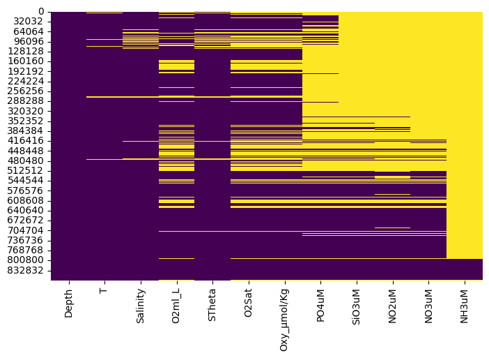

```python
# Visualization of NaN values in the dataframe
plt.rcParams["figure.figsize"] = (8,5)
sns.heatmap(df.isna(), cbar=False, cmap='viridis')
```

```
data frame ripulito dai dati mancanti
righe rimanenti: 64873
```

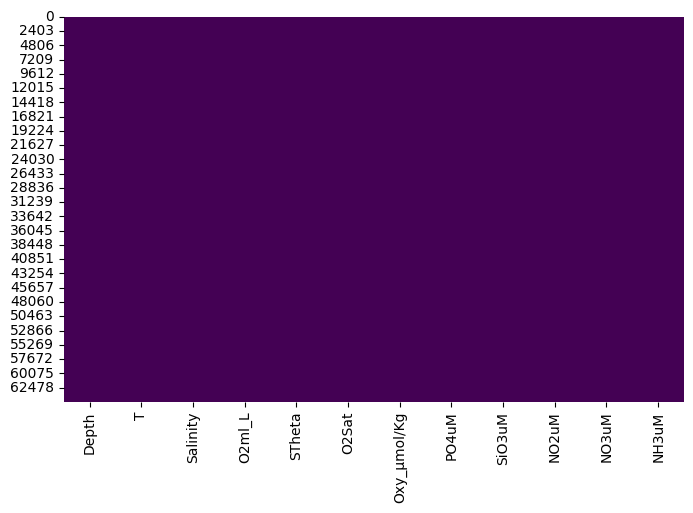

```python
df = df.dropna()  # Overwrite df with the version without NaN values
df = df.reset_index(drop=True)  # Reset the index

# Display the heatmap after cleaning
plt.rcParams["figure.figsize"] = (8,5)
sns.heatmap(df.isna(), cbar=False, cmap='viridis')

print("dataframe cleaned from missing data")
print("remaining rows:", len(df))
```

```python
df.head()
```

<style scoped> .dataframe tbody tr th:only-of-type { vertical-align: middle; } .dataframe tbody tr th { vertical-align: top; } .dataframe thead th { text-align: right; } </style> <thead> <th></th> <th>Depth</th> <th>T</th> <th>Salinity</th> <th>O2ml_L</th> <th>STheta</th> <th>O2Sat</th> <th>Oxy_µmol/Kg</th> <th>PO4uM</th> <th>SiO3uM</th> <th>NO2uM</th> <th>NO3uM</th> <th>NH3uM</th> </thead> <tbody> <th>0</th> <th>1</th> <th>2</th> <th>3</th> <th>4</th> </tbody>

| 0 | 12.14 | 33.537 | 5.46 | 25.427 | 89.7 | 237.7971 | 0.88 | 9.6 | 0.26 | 8.4 | 0.12 |
| --- | --- | --- | --- | --- | --- | --- | --- | --- | --- | --- | --- |
| 2 | 12.14 | 33.537 | 5.46 | 25.427 | 89.7 | 237.7971 | 0.88 | 9.6 | 0.26 | 8.4 | 0.12 |
| 6 | 12.14 | 33.538 | 5.45 | 25.428 | 89.5 | 237.3614 | 0.87 | 9.5 | 0.26 | 8.4 | 0.11 |
| 10 | 12.15 | 33.537 | 5.46 | 25.425 | 89.7 | 237.7976 | 0.87 | 9.5 | 0.26 | 8.4 | 0.13 |
| 20 | 12.15 | 33.538 | 5.46 | 25.426 | 89.7 | 237.7974 | 0.88 | 9.5 | 0.26 | 8.3 | 0.16 |

<p>I now try to plot T and Salinity as functions of the other features, in order to check whether their dependence is linear or more complex.</p>

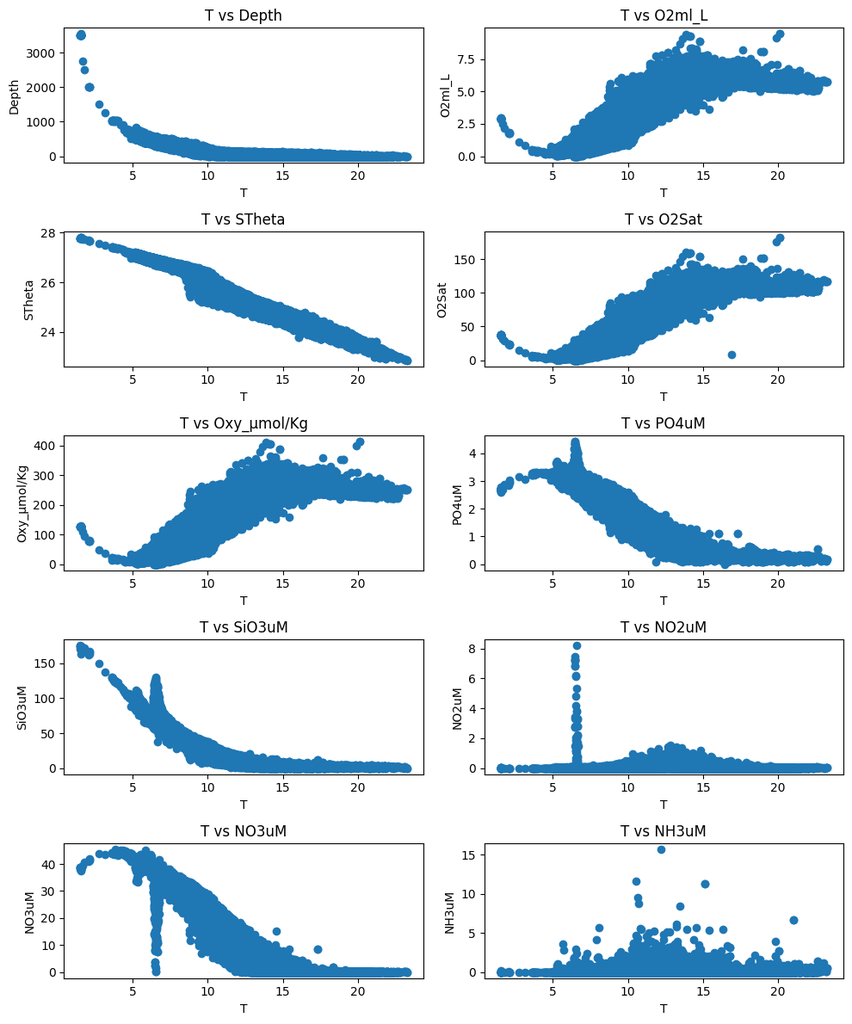

```python
variables = ['Depth', 'O2ml_L', 'STheta', 'O2Sat', 'Oxy_µmol/Kg', 'PO4uM', 'SiO3uM', 'NO2uM', 'NO3uM', 'NH3uM']

# Create a grid with 5 rows and 2 columns
fig, axes = plt.subplots(5, 2, figsize=(10, 12))

# Loop over the variables and axes
for i, var in enumerate(variables):
    ax = axes[i // 2, i % 2]  # Select the correct position
    ax.scatter(df['T'], df[var])
    ax.set_title(f"T vs {var}")
    ax.set_xlabel("T")
    ax.set_ylabel(var)

# Better layout to avoid overlaps
plt.tight_layout()
plt.show()
```

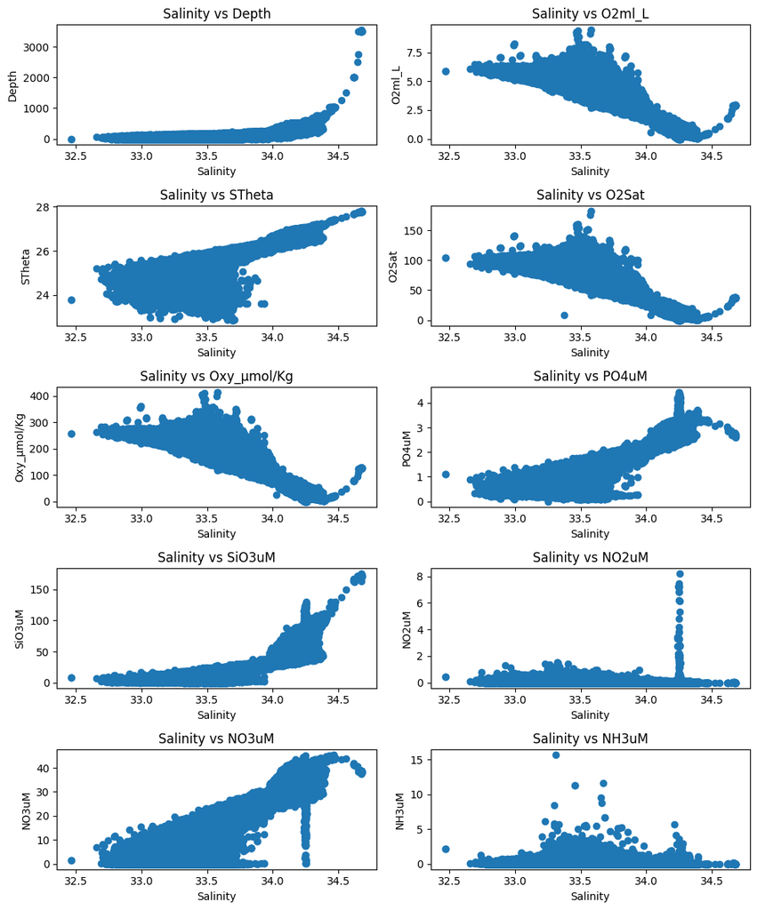

```python
variables = ['Depth', 'O2ml_L', 'STheta', 'O2Sat', 'Oxy_µmol/Kg', 'PO4uM', 'SiO3uM', 'NO2uM', 'NO3uM', 'NH3uM']

# Create a grid with 5 rows and 2 columns
fig, axes = plt.subplots(5, 2, figsize=(10, 12))

# Loop over the variables and axes
for i, var in enumerate(variables):
    ax = axes[i // 2, i % 2]  # Select the correct position
    ax.scatter(df['Salinity'], df[var])
    ax.set_title(f"Salinity vs {var}")
    ax.set_xlabel("Salinity")
    ax.set_ylabel(var)

# Better layout to avoid overlaps
plt.tight_layout()
plt.show()
```

<p>Both for temperature and salinity, the dependence of the labels on the features shows complex patterns that cannot be explained by a simple linear dependence.</p>

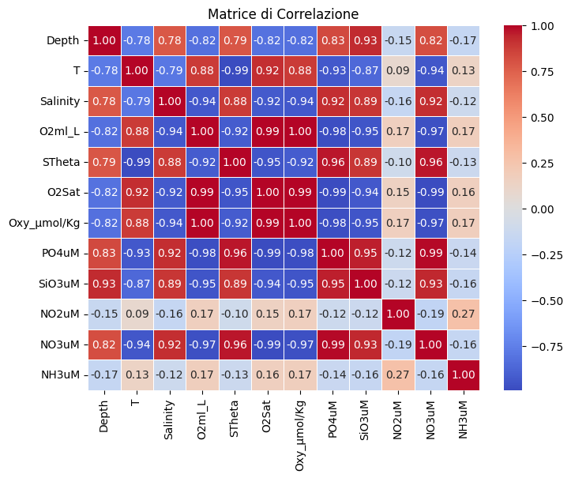

```python
# Compute the correlation matrix
correlation_matrix = df.corr()

# Display the correlation heatmap
plt.figure(figsize=(8,6))
sns.heatmap(correlation_matrix, annot=True, cmap="coolwarm", fmt=".2f", linewidths=0.5)
plt.title("Correlation Matrix")
plt.show()
```

```python
# Define the features (X) and the target variables (y)
X = df.drop(columns=['Salinity', 'T'])  # Features
y = df[['Salinity', 'T']]  # Target variables

# Split the dataset into training and test sets
X_train, X_test, y_train, y_test = train_test_split(X, y, test_size=0.2, random_state=42)
```

<h2 id="Ridge-Regression">**Ridge Regression**</h2><p>Given the rather complicated and varied form of the dependence of the labels on the other variables, a Ridge regression predictor was implemented, together with generalized coordinates, in order to increase the expressiveness of the learning algorithm.</p> <p>Let us first take a step back: the solution of “standard” linear regression is based on the invertibility of $\mathbf{X^TX}$, since the vector of coefficients $\beta$ (in the case of a single target) is given by:</p> <p>$$ \underline{\beta} = (\mathbf{X^TX})^{-1}\mathbf{X^T}y $$</p> <p>More generally, if there are multiple targets, we have:</p> <p>$$ \mathbf{\underline{\beta}} = (\mathbf{X^TX})^{-1}\mathbf{X^TY} $$</p> <p>Moreover:</p>

- If the regression model has too many parameters, or if the data are very noisy, meaning that there are many fluctuations in the data that do not represent a real relationship, the model can “fit too closely” to the training data, also capturing the noise. This phenomenon is called **overfitting**.
- When the model is **overparameterized**, for example when there are many independent variables compared with the available data, it can make very accurate predictions on the training data but fail to generalize to new data, leading to large errors when tested on previously unseen data.
- If some independent variables are strongly correlated with one another (**multicollinearity**), the regression coefficients can become unstable, with large fluctuations in their values. This leads to unreliable solutions that vary unpredictably depending on the training data.

<p>**Regularization** introduces a penalty on the model parameters, namely the coefficients, reducing their magnitude and preventing them from becoming too large. This helps prevent the model from fitting the noise in the data too closely and reduces the model complexity. In the case of **Ridge regularization**, we have:</p> <p>$$ ||\underline{\beta}|| ^ {2} \leq t $$</p> <p>that is:</p> <p>$$ \underline{\hat{\beta}}^{ridge} = argmin_{\beta} \left( \sum_{i=1}^{N}\left(y_i - \beta_{0} - \sum_{j=1}^{p} x_{ij}\beta_j \right)^2 + \lambda \sum_{j=1}^{P}\beta_{j}^2\right) $$</p> <p>$\lambda \geq 0$ is the **complexity parameter** that controls the strength of the penalty. The larger $\lambda$ is, the stronger the penalty. The penalty tends to shrink the coefficients toward 0 and bring them closer to one another. There is a one-to-one correspondence between $\lambda$ and $t$.</p> <p>The cost function is therefore:</p> <p>$$ \mathit{L}(\underline{\beta}) = \sum_{i=1}^{N}(y_i - \hat{y}_i)^2 + \lambda \sum_{j=1}^{p}|\beta_j|^2 = (\vec{y} - \mathbf{X}\underline{\beta})^{T}(\vec{y} - \mathbf{X}\underline{\beta}) + \lambda\underline{\beta}^T\underline{\beta} $$</p> <p>and, by minimizing,</p> <p>$$ \frac{\partial \mathit{L}(\underline{\beta})}{\partial\beta_j} = - \sum 2 (y_i - \underline{x_i}^T\underline{\beta})x_{ij} + 2 \lambda \beta_j $$ $$ \nabla_{\beta} \mathit{L} = -2 \mathbf{X}^T(\vec{y} - \mathbf{X}\underline{\beta}) + 2\lambda\underline{\beta} = 0 $$</p> <p>Hence:</p> <p>$$ -\mathbf{X}^T\vec{y} + \mathbf{X}^T\mathbf{X}\underline{\beta} + \lambda \underline{\beta} = 0 $$</p> <p>that is:</p> <p>$$ \underline{\beta} = (\mathbf{X}^T\mathbf{X} + \lambda I )^{-1}\mathbf{X}^T\vec{y} $$</p> <p>We now move on to generalized features and the implementation of a Mercer kernel.</p> <p>The **generalized design matrix** has dimension $N \times P$:</p> <p>$$ \underline{\underline{X}} = \begin{bmatrix} \phi_{1}(\underline{x}_1) & \phi_{2}(\underline{x}_1) & ... &\phi_{P}(\underline{x}_1) \\ \phi_{1}(\underline{x}_2) & \phi_{2}(\underline{x}_2) & ... &\phi_{P}(\underline{x}_2) \\ \vdots & \vdots& \ddots & \vdots \\ \phi_{1}(\underline{x}_N) & \phi_{2}(\underline{x}_N) & ... &\phi_{P}(\underline{x}_N) \\ \end{bmatrix} = \begin{bmatrix} h(\underline{x}_1)^T\\ h(\underline{x}_2)^T\\ \vdots\\ h(\underline{x}_N)^T\\ \end{bmatrix} $$</p> <p>The best fit for the parameters of the linear predictor with Ridge regularization is given by:</p> <p>$$ \underline{\alpha} = (\mathbf{X}^T\mathbf{X} + \lambda I )^{-1}\mathbf{X}^T\vec{y} = \mathbf{X}^T(\mathbf{X}\mathbf{X}^T + \lambda I )^{-1}\vec{y} $$</p> <p>and the optimal predictor is therefore:</p> <p>$$ f(\underline{x}) = \alpha^T h(\underline{x}) = \vec{y}^T \left( \mathbf{X} \mathbf{X}^T + \lambda I_{N \times N} \right)^{-1} \mathbf{X} h(\underline{x}). $$</p> <p>The form of the last line allows us to apply the **kernel trick**, once we recognize that the elements of the inverted matrix are scalar products in the generalized feature space, namely:</p> <p>$$ [\mathbf{X} \mathbf{X}^T]_{ij} = h(\underline{x}_i)^T h(\underline{x}_j), $$</p> <p>and similarly for the vector $\mathbf{X} h(\underline{x})$. By replacing these scalar products with the kernel, we obtain the final form of our predictor:</p> <p>$$ \hat{f}(\underline{x}) = \sum_{i,j=1}^{N} y_i \left[ K(\underline{x}_i, \underline{x}_j) + \lambda I_{ij} \right]^{-1} K(\underline{x}_j, \underline{x}). $$</p> <p>In the context of this regression model, the **RBF kernel (Radial Basis Function)** was chosen for the feature transformation. The RBF kernel is widely used in machine learning techniques because of its ability to map data into a higher-dimensional space, allowing the model to capture nonlinear relationships between variables. In particular, the use of **Random Fourier Features (RFF)** makes it possible to approximate the RBF kernel efficiently, reducing the computational cost compared with a direct evaluation of the kernel.</p> <p>Regarding **data standardization**, it is a crucial step to ensure that all features are on the same scale. Standardizing the variables ensures that each attribute contributes to the model in a balanced way, preventing variables with larger numerical values from dominating the learning process.</p>

```python
# Standardize the data
scaler = StandardScaler()
X_train_scaled = scaler.fit_transform(X_train)
X_test_scaled = scaler.transform(X_test)

# Apply the Random Fourier Features transformation
rff = RBFSampler(gamma=0.1, n_components=300)

# Create the Ridge model with the Fourier transformation
model = make_pipeline(rff, Ridge(alpha=1.0))

# Train the model
model.fit(X_train_scaled, y_train)

# Make predictions
y_pred = model.predict(X_test_scaled)
```

<h2 id="Random-Fourier-Features-(RFF)">**Random Fourier Features (RFF)**</h2><h2 id="RBF-Kernel-and-the-Computational-Problem">RBF Kernel and the Computational Problem</h2><p>Consider the **Radial Basis Function (RBF) kernel**, defined as:</p> <p>$$ K(x, y) = \exp\left(-\frac{\| x - y \|^2}{2\sigma^2}\right) $$</p> <p>where $x, y \in \mathbb{R}^d$. This kernel is widely used in machine learning to capture nonlinear relationships in data.</p> <p>However, directly using this kernel in kernel-based methods, for example Support Vector Machines or kernel Ridge Regression, requires the construction and inversion of the kernel matrix $K$. These operations are computationally expensive, with complexity $O(n^2)$ in memory and $O(n^3)$ for the inversion.</p> <h2 id="Bochner%E2%80%99s-Theorem-and-the-Connection-with-Fourier-Features">Bochner’s Theorem and the Connection with Fourier Features</h2><p>**Bochner’s theorem** states that any **translation-invariant** kernel function, meaning a function that depends only on $x - y$, such as the RBF kernel, can be expressed as the Fourier transform of its spectral density:</p> <p>$$ K(x, y) = \int_{\mathbb{R}^d} p(z) e^{i z^T (x - y)} dz $$</p> <p>where $p(z)$ represents the **density spectrum** of the kernel, namely its Fourier transform. In the case of the RBF kernel, this distribution is a **normal distribution**:</p> <p>$$ p(z) = \mathcal{N}(z \mid 0, 2\gamma I) $$</p> <p>with $\gamma = \frac{1}{2\sigma^2}$, which represents the bandwidth parameter of the kernel.</p> <p>Using Euler’s identity:</p> <p>$$ e^{i\theta} = \cos(\theta) + i \sin(\theta) $$</p> <p>it is possible to rewrite the kernel as:</p> <p>$$ K(x, y) = \mathbb{E}_{z \sim p(z)} [\cos(z^T x) \cos(z^T y) + \sin(z^T x) \sin(z^T y)] $$</p> <h2 id="Construction-of-Random-Fourier-Features">Construction of Random Fourier Features</h2><p>To avoid explicitly computing the integral above, a Monte Carlo approximation can be used by sampling $m$ vectors $z_1, \dots, z_m$ from the distribution $p(z)$, obtaining the following approximation:</p> <p>$$ K(x, y) \approx \frac{1}{m} \sum_{i=1}^{m} \left[\cos(z_i^T x + b_i) \cos(z_i^T y + b_i)\right] $$</p> <p>where $b_i \sim U(0, 2\pi)$ is a random phase term added to improve the stability of the approximation.</p> <p>Defining the **Random Fourier Features mapping**:</p> <p>$$ \phi(x) = \sqrt{\frac{2}{m}} \begin{bmatrix} \cos(z_1^T x + b_1) \\ \cos(z_2^T x + b_2) \\ \vdots \\ \cos(z_m^T x + b_m) \end{bmatrix} $$</p> <p>we obtain that the scalar product in the transformed space approximates the kernel:</p> <p>$$ K(x, y) \approx \langle \phi(x), \phi(y) \rangle = \phi(x)^T \phi(y) $$</p> <h2 id="Interpretation">Interpretation</h2>

- Instead of computing the kernel $K(x, y)$ directly, a nonlinear transformation of the original space is performed through the function $\phi(x)$.
- The transformation uses cosine functions with random frequencies sampled from a Gaussian distribution, making it possible to approximate the behavior of a kernel-based model using a linear model.
- A more common formulation also includes the sine component, giving the representation:

<p>$$ \phi(x) = \sqrt{\frac{2}{m}} \begin{bmatrix} \cos(z_1^T x + b_1) \\ \sin(z_1^T x + b_1) \\ \cos(z_2^T x + b_2) \\ \sin(z_2^T x + b_2) \\ \vdots \end{bmatrix} $$</p> <p>This formulation improves the kernel approximation and ensures better numerical stability.</p>

- The **Random Fourier Features** approach reduces the computational complexity of using kernels, making it possible to apply kernel-based models even to large datasets.

```python
from sklearn.metrics import mean_squared_error, r2_score

# Compute the MSE and R² separately for each target variable
mse_salnty = mean_squared_error(y_test['Salinity'], y_pred[:, 0])
mse_t_degC = mean_squared_error(y_test['T'], y_pred[:, 1])

r2_salnty = r2_score(y_test['Salinity'], y_pred[:, 0])
r2_t_degC = r2_score(y_test['T'], y_pred[:, 1])

mse = mean_squared_error(y_test, y_pred)
r2 = r2_score(y_test, y_pred)

# Print the results
print(f"MSE (Salinity): {mse_salnty:.4f}")
print(f"MSE (T): {mse_t_degC:.4f}")
print(f"MSE: {mse:.4f}")
print(f"R² Score (Salinity): {r2_salnty:.4f}")
print(f"R² Score (T): {r2_t_degC:.4f}")
print(f"R² Score: {r2:.4f}")
```

```
MSE (Salinity): 0.0028
MSE (T): 0.0522
MSE: 0.0275
R² Score (Salinity): 0.9828
R² Score (T): 0.9961
R² Score: 0.9894
```

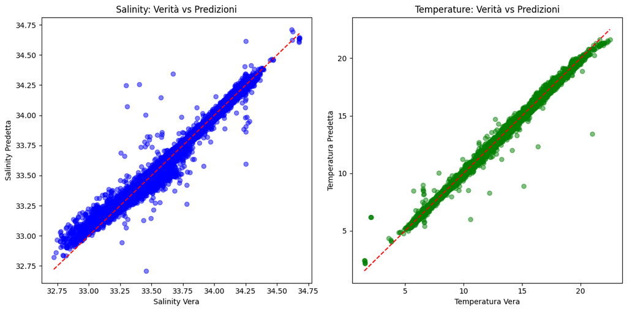

```python
# Predictions for Salinity and T
y_pred_Salinity = y_pred[:, 0]  # The first column is Salinity
y_pred_temp = y_pred[:, 1]  # The second column is temperature

# Plot for Salinity
plt.figure(figsize=(12, 6))

# Scatter plot of actual vs predicted Salinity
plt.subplot(1, 2, 1)
plt.scatter(y_test['Salinity'], y_pred_Salinity, color='blue', alpha=0.5)
plt.plot([y_test['Salinity'].min(), y_test['Salinity'].max()],
         [y_test['Salinity'].min(), y_test['Salinity'].max()], color='red', linestyle='--')
plt.title('Salinity: Actual vs Predictions')
plt.xlabel('Actual Salinity')
plt.ylabel('Predicted Salinity')

# Plot for Temperature
# Scatter plot of actual vs predicted Temperature
plt.subplot(1, 2, 2)
plt.scatter(y_test['T'], y_pred_temp, color='green', alpha=0.5)
plt.plot([y_test['T'].min(), y_test['T'].max()],
         [y_test['T'].min(), y_test['T'].max()], color='red', linestyle='--')
plt.title('Temperature: Actual vs Predictions')
plt.xlabel('Actual Temperature')
plt.ylabel('Predicted Temperature')

# Show the plots
plt.tight_layout()
plt.show()
```

<h2 id="Final-Remarks">**Final Remarks**</h2><p>In the context of the CalCOFI project, the prediction of salinity and temperature was addressed using a **Ridge regression model**. The choice of applying a **Gaussian kernel**, approximated through **Random Fourier Features**, made it possible to obtain a good compromise between accuracy and computational efficiency, reducing the computational cost of the kernel compared with its exact form.</p> <p>The results obtained show that the model is able to capture the relationships between the variables well, with satisfactory predictions for both salinity and temperature as functions of the other features in the dataset. The use of Random Fourier Features made it possible to extend Ridge regression to high-dimensional feature spaces, improving the flexibility of the model without incurring excessive overfitting.</p> <p>A more in-depth analysis could include evaluating the models on new datasets to test the generalizability of the model. In addition, adopting other regularization techniques or using different kernels could lead to further performance improvements.</p> <p>Overall, the results suggest that the adopted approach is promising for the prediction of oceanographic variables and that it can be extended to more complex contexts.</p>

<h2 id="References">**References**</h2><p>Random Fourier Features: https://random-walks.org/book/papers/rff/rff.html</p>